# Lecture 5: Manipulate data frames with dplyr

### (Copied from R programming lecture notes, use for code reference only.)

## Topics today

### 1. Recall: data frames

### 2. Motivation for using `dplyr`

### 3. Using `dplyr`

### 4. Exercise

## 1. Recall: data frames

- **A data frame is a special type of list that contains data in a format that allows for easier manipulation, reshaping, and open-ended analysis**
- **Data frames are tightly coupled collections of variables. It is one of the more important constructs you will encounter when using R so learn all you can about it**
- **A data frame is an analogue to the Excel spreadsheet but is much more flexible for storing, manipulating, and analyzing data**
- **Data frames can be constructed from existing vectors, lists, or matrices. Many times they are created by reading in comma delimited files, (CSV files), using the read.table command**
- **Once you become accustomed to working with data frames, R becomes so much easier to use**

There are various ways to select, remove, or exclude rows and columns:

```r
mtcars[mtcars$mpg >= 30.0,]
```

```
##                 mpg cyl disp  hp drat    wt  qsec vs am gear carb
## Fiat 128       32.4   4 78.7  66 4.08 2.200 19.47  1  1    4    1
## Honda Civic    30.4   4 75.7  52 4.93 1.615 18.52  1  1    4    2
## Toyota Corolla 33.9   4 71.1  65 4.22 1.835 19.90  1  1    4    1
## Lotus Europa   30.4   4 95.1 113 3.77 1.513 16.90  1  1    5    2
```

```r
mtcars[mtcars$mpg >= 30.0,2:6]
```

```
##                cyl disp  hp drat    wt
## Fiat 128         4 78.7  66 4.08 2.200
## Honda Civic      4 75.7  52 4.93 1.615
## Toyota Corolla   4 71.1  65 4.22 1.835
## Lotus Europa     4 95.1 113 3.77 1.513
```

```r
mtcars[mtcars$mpg >= 30.0 & mtcars$cyl < 6,]
```

```
##                 mpg cyl disp  hp drat    wt  qsec vs am gear carb
## Fiat 128       32.4   4 78.7  66 4.08 2.200 19.47  1  1    4    1
## Honda Civic    30.4   4 75.7  52 4.93 1.615 18.52  1  1    4    2
## Toyota Corolla 33.9   4 71.1  65 4.22 1.835 19.90  1  1    4    1
## Lotus Europa   30.4   4 95.1 113 3.77 1.513 16.90  1  1    5    2
```

What columns appear to be factors ? Variables with only a few different unique values perhaps ?

```r
str(mtcars)
```

```
## 'data.frame':    32 obs. of  11 variables:
##  $ mpg : num  21 21 22.8 21.4 18.7 18.1 14.3 24.4 22.8 19.2 ...
##  $ cyl : num  6 6 4 6 8 6 8 4 4 6 ...
##  $ disp: num  160 160 108 258 360 ...
##  $ hp  : num  110 110 93 110 175 105 245 62 95 123 ...
##  $ drat: num  3.9 3.9 3.85 3.08 3.15 2.76 3.21 3.69 3.92 3.92 ...
##  $ wt  : num  2.62 2.88 2.32 3.21 3.44 ...
##  $ qsec: num  16.5 17 18.6 19.4 17 ...
##  $ vs  : num  0 0 1 1 0 1 0 1 1 1 ...
##  $ am  : num  1 1 1 0 0 0 0 0 0 0 ...
##  $ gear: num  4 4 4 3 3 3 3 4 4 4 ...
##  $ carb: num  4 4 1 1 2 1 4 2 2 4 ...
```

See how many unqiue values each column takes on

```r
sapply(mtcars, function(x) length(unique(x)))
```

```
##  mpg  cyl disp   hp drat   wt qsec   vs   am gear carb
##   25    3   27   22   22   29   30    2    2    3    6
```

## 2. Motivation for using dplyr package:

### 2.1 What is `dplyr`?

`dplyr` is an add on package designed to efficiently transform and summarize tablular data such as data frames. The package has a number of functions (“verbs”) that perform a number of data manipulation tasks:

- **Filtering rows**
- **Select specific columns**
- **Re-ordering or arranging rows**
- **Summarizing and aggregating data**

One of the **unique** strengths of `dplyr` is that it implements what is known as a **Split-Apply-Combine** technique that we will explore in this session.

### 2.2 Features of `dplyr` package

- `dplyr` is designed to work with data frames but it can also connect to relational databases that are locally or remotely available.
- Access to data frames or databases is accomplished uisng the same set of tools. You don’t have to use different commands.
- Relative to databases you use the “verbs” provided with dplyr that in turn are translated into the appropriate SQL statements necessary to interact with the databases.

### 2.3 How to install dplyr?

```r
# install the package
install.packages("dplyr")
# Loads the package
library(dplyr)
# Launches a browser to explore
browseVignettes(package = "dplyr")
```

This slide deck references “Becoming a data ninja with dplyr” https: //speakerdeck.com/dpastoor/becoming-a-data-ninja-with-dplyr and the dplyr tutorial http://genomicsclass.github.io/book/pages/dplyr_tutorial.html.

## 3. Using `dplyr` package

### 3.1 Take another look at data frame objects:

- A data frame is a set of columns. Every column is same length but of possibly different types.
- It has characteristics of both a matrix and a vector, (within each column is the same data type),
- Different columns can have different data types.
- Bracket notation offers a convenient way to search through the data drame

```r
head(mtcars,12)
```

```
##                    mpg cyl  disp  hp drat    wt  qsec vs am gear carb
## Mazda RX4         21.0   6 160.0 110 3.90 2.620 16.46  0  1    4    4
## Mazda RX4 Wag     21.0   6 160.0 110 3.90 2.875 17.02  0  1    4    4
## Datsun 710        22.8   4 108.0  93 3.85 2.320 18.61  1  1    4    1
## Hornet 4 Drive    21.4   6 258.0 110 3.08 3.215 19.44  1  0    3    1
## Hornet Sportabout 18.7   8 360.0 175 3.15 3.440 17.02  0  0    3    2
## Valiant           18.1   6 225.0 105 2.76 3.460 20.22  1  0    3    1
## Duster 360        14.3   8 360.0 245 3.21 3.570 15.84  0  0    3    4
## Merc 240D         24.4   4 146.7  62 3.69 3.190 20.00  1  0    4    2
## Merc 230          22.8   4 140.8  95 3.92 3.150 22.90  1  0    4    2
## Merc 280          19.2   6 167.6 123 3.92 3.440 18.30  1  0    4    4
## Merc 280C         17.8   6 167.6 123 3.92 3.440 18.90  1  0    4    4
## Merc 450SE        16.4   8 275.8 180 3.07 4.070 17.40  0  0    3    3
```

There are some common activites associated with a data frame:

- **filter** - find observations satisfying some condition(s)
- **select** - selecting specific columns by name
- **mutate** - adding new columns or changing existing ones
- **arrange** - reorder or sort the rows
- **summarize** - do some aggregation or summary by groups

### 3.2 Filter

```r
df <- data.frame(id = 1:5, gender = c("MALE","MALE","FEMALE","MALE","FEMALE"), age = c(70,76,60,64,68))

df
```

```
##   id gender age
## 1  1   MALE  70
## 2  2   MALE  76
## 3  3 FEMALE  60
## 4  4   MALE  64
## 5  5 FEMALE  68
```

```r
library(dplyr)
filter(df,gender == "FEMALE")
```

```
##   id gender age
## 1  3 FEMALE  60
## 2  5 FEMALE  68
```

```r
filter(df, id %in% c(1,3,5))
```

```
##   id gender age
## 1  1   MALE  70
## 2  3 FEMALE  60
## 3  5 FEMALE  68
```

### 3.3 Mutate

```r
mutate(df, meanage = mean(age))
```

```
##   id gender age meanage
## 1  1   MALE  70    67.6
## 2  2   MALE  76    67.6
## 3  3 FEMALE  60    67.6
## 4  4   MALE  64    67.6
## 5  5 FEMALE  68    67.6
```

Here we create a new column designed to tell us if a given observation has an age that is greater than or equal to the average age. We create a variable called old young and assing a value of “Y” if the are above the mean age and a value of “N” if they are not.

```r
mutate(df, old_young = ifelse(df$age >= mean(df$age), "Y", "N"))
```

```
##   id gender age old_young
## 1  1   MALE  70         Y
## 2  2   MALE  76         Y
## 3  3 FEMALE  60         N
## 4  4   MALE  64         N
## 5  5 FEMALE  68         Y
```

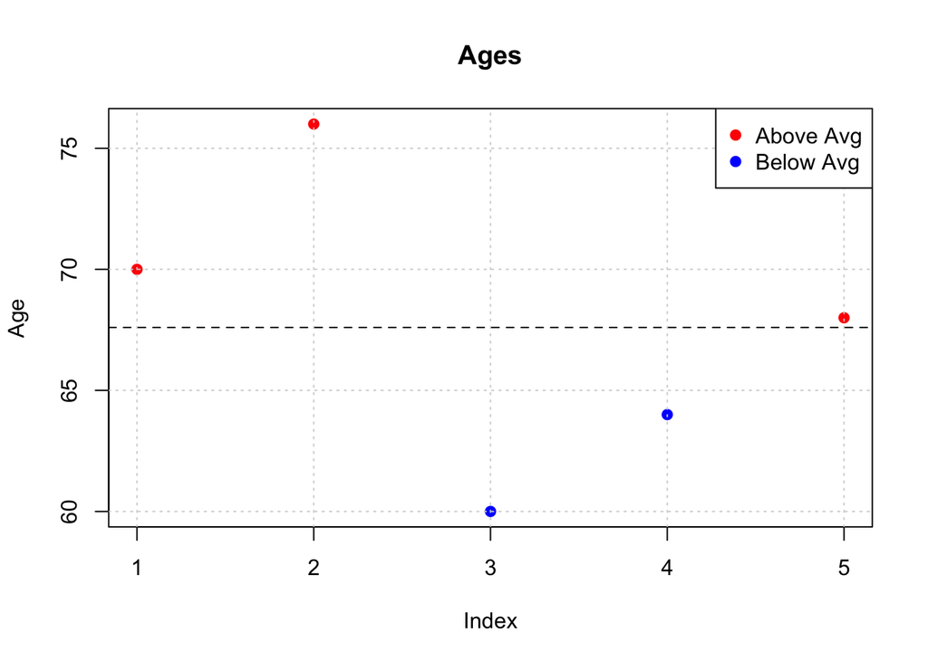

```r
tmp <- mutate(df, color = ifelse(age > mean(age),"red","blue"))
plot(tmp$age, col = tmp$color, type = "p",pch = 19,main = "Ages", ylab = "Age")
grid()
abline(h=mean(tmp$age),lty=2)
legend("topright", c("Above Avg","Below Avg"), col=c("red","blue"), pch=19)
```

### 3.4 Arrange

Use arrange for sorting the data frame by a column(s).

```r
# Sort df by age from highest to lowest
arrange(df, desc(age))
```

```
##   id gender age
## 1  2   MALE  76
## 2  1   MALE  70
## 3  5 FEMALE  68
## 4  4   MALE  64
## 5  3 FEMALE  60
```

```r
# Sort df by gender (alphabetically) and then by age
# from highest to lowest
arrange(df, gender,desc(age))
```

```
##   id gender age
## 1  5 FEMALE  68
## 2  3 FEMALE  60
## 3  2   MALE  76
## 4  1   MALE  70
## 5  4   MALE  64
```

### 3.5 Select

Select allows us to select groups of columns from a data frame。

```r
select(df,gender,id,age) # Reorder the columns
```

```
##   gender id age
## 1   MALE  1  70
## 2   MALE  2  76
## 3 FEMALE  3  60
## 4   MALE  4  64
## 5 FEMALE  5  68
```

```r
select(df,-age) # Select all but the age column
```

```
##   id gender
## 1  1   MALE
## 2  2   MALE
## 3  3 FEMALE
## 4  4   MALE
## 5  5 FEMALE
```

```r
select(df,id:age) # Can use : to select a range
```

```
##   id gender age
## 1  1   MALE  70
## 2  2   MALE  76
## 3  3 FEMALE  60
## 4  4   MALE  64
## 5  5 FEMALE  68
```

You can select by regular expressions or numeric patterns

```r
library(ggplot2)
data(diamonds)
head(diamonds)
```

```
## # A tibble: 6 x 10
##   carat cut       color clarity depth table price     x     y     z
##   <dbl> <ord>     <ord> <ord>   <dbl> <dbl> <int> <dbl> <dbl> <dbl>
## 1 0.23  Ideal     E     SI2      61.5    55   326  3.95  3.98  2.43
## 2 0.21  Premium   E     SI1      59.8    61   326  3.89  3.84  2.31
## 3 0.23  Good      E     VS1      56.9    65   327  4.05  4.07  2.31
## 4 0.290 Premium   I     VS2      62.4    58   334  4.2   4.23  2.63
## 5 0.31  Good      J     SI2      63.3    58   335  4.34  4.35  2.75
## 6 0.24  Very Good J     VVS2     62.8    57   336  3.94  3.96  2.48
```

```r
head(select(diamonds,starts_with("c")))
```

```
## # A tibble: 6 x 4
##   carat cut       color clarity
##   <dbl> <ord>     <ord> <ord>
## 1 0.23  Ideal     E     SI2
## 2 0.21  Premium   E     SI1
## 3 0.23  Good      E     VS1
## 4 0.290 Premium   I     VS2
## 5 0.31  Good      J     SI2
## 6 0.24  Very Good J     VVS2
```

```r
head(select(diamonds,ends_with("t")))
```

```
## # A tibble: 6 x 2
##   carat cut
##   <dbl> <ord>
## 1 0.23  Ideal
## 2 0.21  Premium
## 3 0.23  Good
## 4 0.290 Premium
## 5 0.31  Good
## 6 0.24  Very Good
```

Another example:

```r
testdf <- expand.grid(m_1=seq(60,70,10),age=c(25,32),m_2=seq(50,60,10))

head(testdf, 4)
```

```
##   m_1 age m_2
## 1  60  25  50
## 2  70  25  50
## 3  60  32  50
## 4  70  32  50
```

```r
head(select(testdf,matches("_")), 2)
```

```
##   m_1 m_2
## 1  60  50
## 2  70  50
```

```r
head(select(testdf,contains("_")), 2)
```

```
##   m_1 m_2
## 1  60  50
## 2  70  50
```

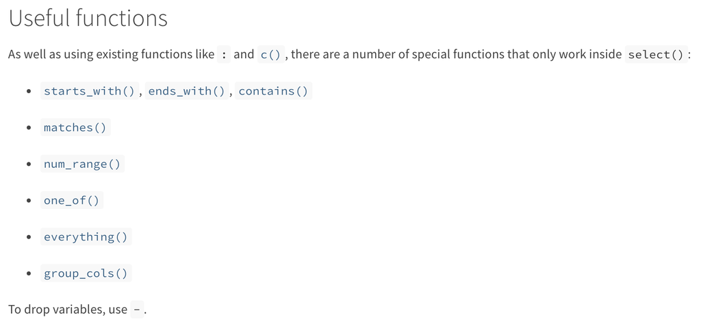

[tutorial_reference](https://dplyr.tidyverse.org/reference/select.html)

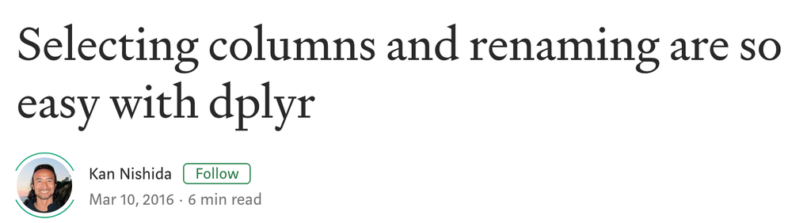

[blog_reference](https://blog.exploratory.io/selecting-columns-809bdd1ef615)

### 3.6 group_by

`group_by` let you organize a data frame by some factor or grouping variable.

```r
df
```

```
##   id gender age
## 1  1   MALE  70
## 2  2   MALE  76
## 3  3 FEMALE  60
## 4  4   MALE  64
## 5  5 FEMALE  68
```

```r
group_by(df,gender) # Hmm. Did this really do anything ?
```

```
## # A tibble: 5 x 3
## # Groups:   gender [2]
##      id gender   age
##   <int> <fct>  <dbl>
## 1     1 MALE      70
## 2     2 MALE      76
## 3     3 FEMALE    60
## 4     4 MALE      64
## 5     5 FEMALE    68
```

### 3.7 Summarize

```r
summarize(group_by(df,gender),total=n())
```

```
## # A tibble: 2 x 2
##   gender total
##   <fct>  <int>
## 1 FEMALE     2
## 2 MALE       3
```

```r
summarize(group_by(df,gender),av_age=mean(age))
```

```
## # A tibble: 2 x 2
##   gender av_age
##   <fct>   <dbl>
## 1 FEMALE     64
## 2 MALE       70
```

```r
summarize(group_by(df,gender),av_age=mean(age),total=n())
```

```
## # A tibble: 2 x 3
##   gender av_age total
##   <fct>   <dbl> <int>
## 1 FEMALE     64     2
## 2 MALE       70     3
```

### 3.8 Joining data frames

```r
idatime <- data.frame(id=rep(1:3,each=2),time=rep(0:1,each=3))

idawt <- data.frame(id=c(1,2,4),wt=c(110,130,115))
```

#### Inner joins - `inner_join(x,y)`

Will return all rows from x where there are matching values in y, and all columns from x and y

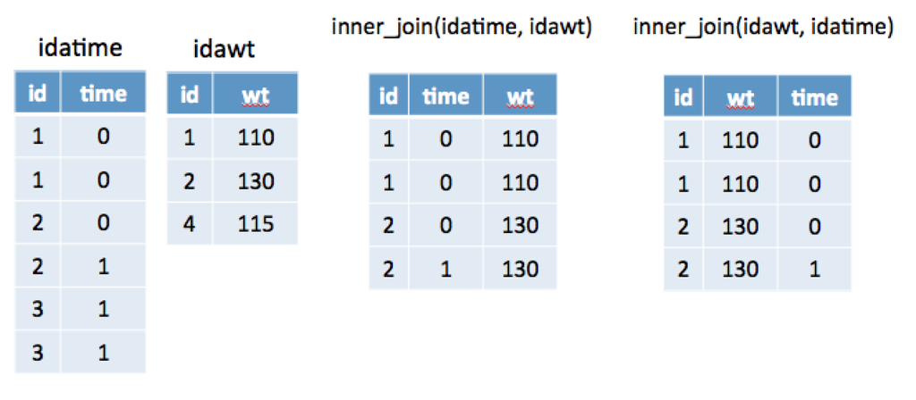

```r
inner_join(idatime,idawt)
```

```
##   id time  wt
## 1  1    0 110
## 2  1    0 110
## 3  2    0 130
## 4  2    1 130
```

#### Joining data frames - `left_join(x,y)`

return all rows from x, and all columns from x and y

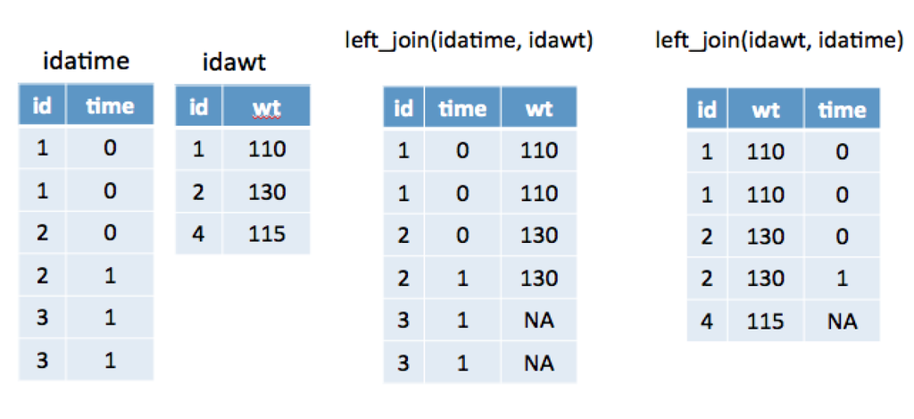

#### Joining data frames - `anti_join(x,y)`

returns all rows from x where there are not any matching values in y, keeping just the columns from x

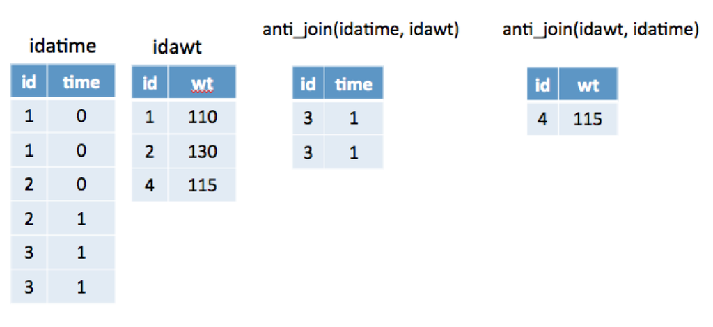

#### Joining data frames - `semi_join(x,y)`

Return all rows from x where there are matching values in y, keeping just columns from x

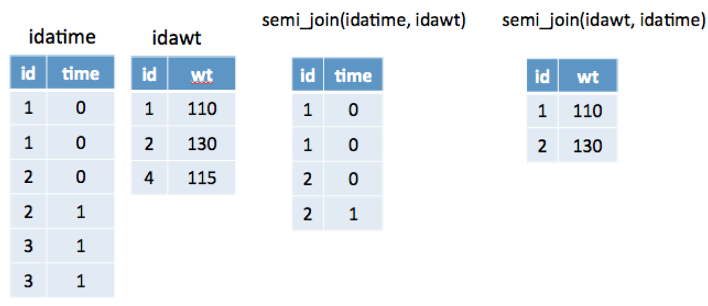

## 4. **pipe** operator

- This is nice.But do you really need dplyr to do this ?
- No but it makes it a lot easier.

```r
df
```

```
##   id gender age
## 1  1   MALE  70
## 2  2   MALE  76
## 3  3 FEMALE  60
## 4  4   MALE  64
## 5  5 FEMALE  68
```

```r
tapply(df$age,df$gender,mean) # tapply function
```

```
## FEMALE   MALE
##     64     70
```

```r
aggregate(age~gender,data=df,mean) # aggregate works also
```

```
##   gender age
## 1 FEMALE  64
## 2   MALE  70
```

```r
lapply(split(df,df$gender),function(x) mean(x$age)) # complicated
```

```
## $FEMALE
## [1] 64
##
## $MALE
## [1] 70
```

How we can do this using pipe operator?

```r
df %>% group_by(gender) %>% summarize(avg=mean(age))
```

```
## # A tibble: 2 x 2
##   gender   avg
##   <fct>  <dbl>
## 1 FEMALE    64
## 2 MALE      70
```

```r
df %>% group_by(gender) %>% summarize(avg=mean(age),total=n())
```

```
## # A tibble: 2 x 3
##   gender   avg total
##   <fct>  <dbl> <int>
## 1 FEMALE    64     2
## 2 MALE      70     3
```

```r
df %>% filter(gender == "MALE") %>% summarize(med_age=median(age))
```

```
##   med_age
## 1      70
```

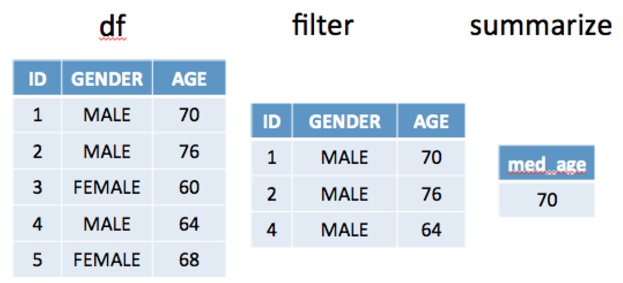

### 4.1 Where this **pipe** operator comes from

- Before moving forward let us consider the “pipe” operator that is included with the `magrittr` package. This is used to make it possible to “pipe” the results of one command into another command and so on.
- The inspiration for this comes from the UNIX/LINUX operating system where pipes are used all the time. So in effect using “pipes” is nothing new in the world of research computation.
- **Warning**: Once you get used to pipes it is hard to go back to not using them

### 4.2 Using **pipe** operator

Let’s use the mtcars data frame to illustrate the basics of the piping mechanism as used by dplyr.

Here we will select the mpg and am column from mtcars and view the top 5 rows.

```r
head(select(mtcars, mpg, am),5)
```

```
##                    mpg am
## Mazda RX4         21.0  1
## Mazda RX4 Wag     21.0  1
## Datsun 710        22.8  1
## Hornet 4 Drive    21.4  0
## Hornet Sportabout 18.7  0
```

Here we will select the mpg and am column from mtcars and view the top 5 rows but using dplyr and the piping operator. Instead of nesting functions (reading from the inside to the outside), the idea of of piping is to read the functions from left to right.

```r
mtcars %>% select(mpg, am) %>% head(5)
```

```
##                    mpg am
## Mazda RX4         21.0  1
## Mazda RX4 Wag     21.0  1
## Datsun 710        22.8  1
## Hornet 4 Drive    21.4  0
## Hornet Sportabout 18.7  0
```

### 4.3 A more complicated example

- Using the built in mtcars dataframe filter out records where the wt is greater than 3.3 tons.
- Then create a column called ab be (Y or N) that indicates whether that observation’s mpg is greater (or not) than the average mpg for the filtered set.
- Then present the average mpg for each group

```r
mtcars %>% filter(wt > 3.3) %>%
mutate(ab_be=ifelse(mpg > mean(mpg),"Y","N") ) %>%
group_by(ab_be) %>% summarize(mean_mpg=mean(mpg))
```

```
## # A tibble: 2 x 2
##   ab_be mean_mpg
##   <chr>    <dbl>
## 1 N         13.8
## 2 Y         18.1
```

- First step: Using the built in mtcars dataframe filter out records where the wt is greater than 3.3 tons.

```r
mtcars %>% filter(wt > 3.3)
```

```
##     mpg cyl  disp  hp drat    wt  qsec vs am gear carb
## 1  18.7   8 360.0 175 3.15 3.440 17.02  0  0    3    2
## 2  18.1   6 225.0 105 2.76 3.460 20.22  1  0    3    1
## 3  14.3   8 360.0 245 3.21 3.570 15.84  0  0    3    4
## 4  19.2   6 167.6 123 3.92 3.440 18.30  1  0    4    4
## 5  17.8   6 167.6 123 3.92 3.440 18.90  1  0    4    4
## 6  16.4   8 275.8 180 3.07 4.070 17.40  0  0    3    3
## 7  17.3   8 275.8 180 3.07 3.730 17.60  0  0    3    3
## 8  15.2   8 275.8 180 3.07 3.780 18.00  0  0    3    3
## 9  10.4   8 472.0 205 2.93 5.250 17.98  0  0    3    4
## 10 10.4   8 460.0 215 3.00 5.424 17.82  0  0    3    4
## 11 14.7   8 440.0 230 3.23 5.345 17.42  0  0    3    4
## 12 15.5   8 318.0 150 2.76 3.520 16.87  0  0    3    2
## 13 15.2   8 304.0 150 3.15 3.435 17.30  0  0    3    2
## 14 13.3   8 350.0 245 3.73 3.840 15.41  0  0    3    4
## 15 19.2   8 400.0 175 3.08 3.845 17.05  0  0    3    2
## 16 15.0   8 301.0 335 3.54 3.570 14.60  0  1    5    8
```

- Second step: create a column called ab be (Y or N) that indicates whether that observation’s mpg is greater (or not) than the average mpg for the filtered set.

```r
mtcars %>% filter(wt > 3.3) %>%
mutate(ab_be=ifelse(mpg > mean(mpg),"Y","N") )
```

```
##     mpg cyl  disp  hp drat    wt  qsec vs am gear carb ab_be
## 1  18.7   8 360.0 175 3.15 3.440 17.02  0  0    3    2     Y
## 2  18.1   6 225.0 105 2.76 3.460 20.22  1  0    3    1     Y
## 3  14.3   8 360.0 245 3.21 3.570 15.84  0  0    3    4     N
## 4  19.2   6 167.6 123 3.92 3.440 18.30  1  0    4    4     Y
## 5  17.8   6 167.6 123 3.92 3.440 18.90  1  0    4    4     Y
## 6  16.4   8 275.8 180 3.07 4.070 17.40  0  0    3    3     Y
## 7  17.3   8 275.8 180 3.07 3.730 17.60  0  0    3    3     Y
## 8  15.2   8 275.8 180 3.07 3.780 18.00  0  0    3    3     N
## 9  10.4   8 472.0 205 2.93 5.250 17.98  0  0    3    4     N
## 10 10.4   8 460.0 215 3.00 5.424 17.82  0  0    3    4     N
## 11 14.7   8 440.0 230 3.23 5.345 17.42  0  0    3    4     N
## 12 15.5   8 318.0 150 2.76 3.520 16.87  0  0    3    2     N
## 13 15.2   8 304.0 150 3.15 3.435 17.30  0  0    3    2     N
## 14 13.3   8 350.0 245 3.73 3.840 15.41  0  0    3    4     N
## 15 19.2   8 400.0 175 3.08 3.845 17.05  0  0    3    2     Y
## 16 15.0   8 301.0 335 3.54 3.570 14.60  0  1    5    8     N
```

- Third step: then present the average mpg for each group as defined by ab_be

```r
mtcars %>% filter(wt > 3.3) %>%
mutate(ab_be=ifelse(mpg > mean(mpg),"Y","N") ) %>%
group_by(ab_be) %>% summarize(mean_mpg=mean(mpg))
```

```
## # A tibble: 2 x 2
##   ab_be mean_mpg
##   <chr>    <dbl>
## 1 N         13.8
## 2 Y         18.1
```

This could then be chained to the ggplot command

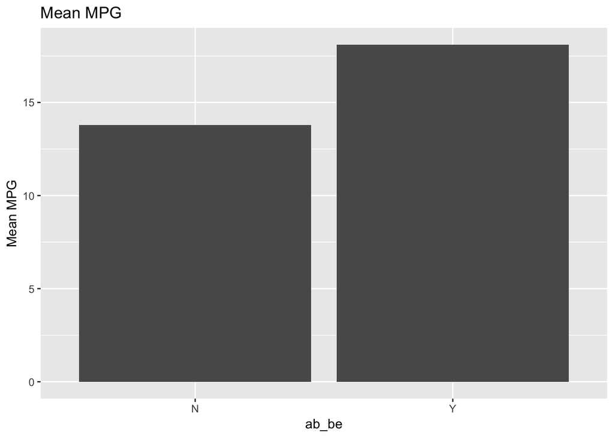

```r
mtcars %>% filter(wt > 3.3) %>%
mutate(ab_be=ifelse(mpg > mean(mpg),"Y","N") ) %>%
group_by(ab_be) %>% summarize(mean_mpg=mean(mpg)) %>%
ggplot(aes(x=ab_be,y=mean_mpg)) + geom_bar(stat="identity") +
ggtitle("Mean MPG") + labs(x = "ab_be", y = "Mean MPG")
```

### 4. Exercise

Now it is your turn. Let’s do some exercises.

```r
url <- "https://www.dropbox.com/s/ayp64u1u5o84qws/msleep_ggplot2.csv?dl=1"
library(readr)
download.file(url,"msleep_ggplot2.csv")
msleep <- read_csv("msleep_ggplot2.csv")
names(msleep)
```

```
##  [1] "name"         "genus"        "vore"         "order"
##  [5] "conservation" "sleep_total"  "sleep_rem"    "sleep_cycle"
##  [9] "awake"        "brainwt"      "bodywt"
```

Here is a description of the columns / variables

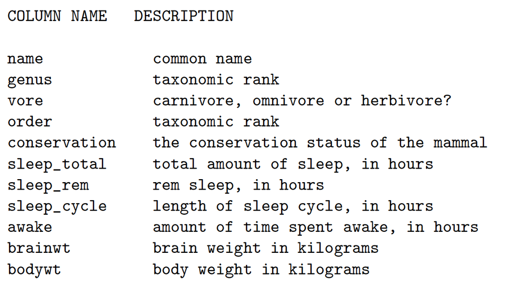

Using the msleep data frame let’s do the following activities and answer some questions. Try to use the chaining operator:

- Select the name and sleep total columns
- Using the colon operator select all columns between name and order
- Select all columns that begin with “sl”
- Filter the data frame to find only rows with a sleep total >= 16
- Filter the rows for mammals that sleep a total of more than 16 hours and have a body weight of greater than 1 kilogram
- Arrange the data frame using the `order` column

For these you will need to use the chaining operator:

- Select three columns, nmae, order and sleep_total, from msleep, arrange the rows by the taxonomic order and then arrange the rows by sleep total. Finally show the head of the final data frame
- Same as above, except here we filter the rows for mammals that sleep for 16 or more hours instead of showing the head of the final data frame
- Use the mutate function to create a new column called rem proportion which is the ratio of rem sleep to total amount of sleep
- Use the `summarize()` function: to compute the average number of hours of sleep, apply the `mean()` function to the column sleep total and call the summary value avg sleep.
- Group the msleep data frame by taxanomic order and then summarize the mean sleep total
- Same as above except summarize the mean, max, and min sleep total